# Session Three - Introduction to Version Control Systems

## Using Git and GitHub in RStudio

RStudio has made version controlling files very easy, we just have to start with an RStudio Project. RStudio projects is platform on RStudio where a collection of different work can be managed together even though they might have different working directories, workspace, history and source documents.

We can create an RStudio project from a new directory (with nothing in it), an existing directory (with files), or clone a version controlled repository.

As an example, we are going to convert our “learningGit” repository into an RStudio project, that way, we can stage, commit and push files right in RStudio without using Git bash or Terminal.

To turn “learningGit” into an RStudio project, click **File** then **New project** and from the pop-up window click **Existing Directory**. Locate where you have saved your repo using **Browse** and click **Create project** and RStudio will open a new session in your new project. Something like this:

[figure not shown]

Now let’s see how super easy it is to add, commit and push a file. Let’s create a new file in R, we can call it **newscript.R** and save it. This is how our project looks like with the new file:

[figure not shown]

My RStudio layout is different from default layout (I changed it to be able to write on one side and view console on the other side), but you should have the same pane’s. From **Git pane** next to environment and History, do you see some question marks next to some files, this means these files are not being tracked, for our new file, click the **Staged** check box and click **Commit** located just below the pane’s bar. A new window will pop-up, type in a commit message on the right hand side like this:

[figure not shown]

Finish by clicking **Commit** button and we should have staged and committed “newscript.R”. To upload to our GitHub account, we simply click **Push** while at “Git pane” and we would have a successful “push” made to our account: Confirm by opening your GitHub “learningGit” repo.

[figure not shown]

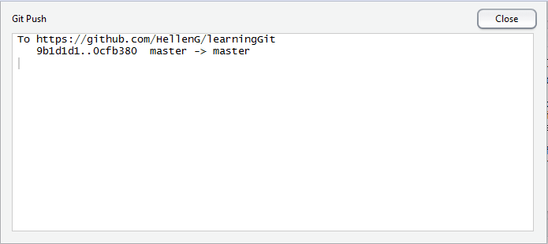

I now leave you to attempt to make a new directory and version control it as well as look for a public repo to clone (consider “https://github.com/hadley/adv-r”).

# References

1. Pro GIT - Session’s Reference Book on matters Git and GitHub: *https://progit2.s3.amazonaws.com/en/2016-01-30-9e7cf/progit-en.1005.pdf) (main reference point)*
2. Version Control with Git by Michael Koby (of CodeCast.tv); *http://codecasts.tv/*. Considers it a video demonstrating Pro Git Book
3. Basic Git Command Line Reference for Windows Users: *https://www.codeproject.com/Articles/457305/Basic-Git-Command-Line-Reference-for-Windows-Users*
4. RStudio Projects: *https://support.rstudio.com/hc/en-us/articles/200526207*
5. Version Control in RStudio: *https://support.rstudio.com/hc/en-us/articles/200532077-Version-Control-with-Git-and-SVN*